# Лабораторная работа №9

Операционные системы

Панина Ж. В.

Российский университет дружбы народов, Москва, Россия

10 апреля 2025

# Информация

## Докладчик

- Панина Жанна Валерьевна
- НКАбд-02-24, студ. билет № 1132246710
- студент направления “Компьютерные и информационные науки”
- Российский университет дружбы народов
- 1132246710@pfur.ru
- https://github.com/zvpanina/study_2024-2025_os-intro

# Вводная часть

## Актуальность

Изучение командной оболочки Midnight Commander (MC) актуально, поскольку этот файловый менеджер остается востребованным инструментом в системном администрировании и работе с Unix-подобными операционными системами. Освоение MC позволяет эффективно управлять файлами и каталогами в терминальном режиме (что критично для серверов без графического интерфейса); автоматизировать задачи за счет встроенных команд и скриптов; понимать основы навигации в CLI (Command Line Interface), что является базовым навыком для IT-специалистов. В эпоху облачных технологий и удалённого администрирования умение работать с текстовыми интерфейсами остаётся ключевым, а MC — один из самых удобных инструментов для этого.

## Объект и предмет исследования

### Объект исследования:

Командная оболочка Midnight Commander.

### Предмет исследования:

Функциональные возможности MC для управления файлами и каталогами, их практическое применение.

## Цели и задачи

Цель работы - освоение основных возможностей командной оболочки Midnight Commander. Приобретение навыков практической работы по просмотру каталогов и файлов; манипуляций с ними.

### Задачи:

1. Изучите информацию о mc, вызвав в командной строке man mc.
2. Запустите из командной строки mc, изучите его структуру и меню.
3. Выполните несколько операций в mc, используя управляющие клавиши (операции с панелями; выделение/отмена выделения файлов, копирование/перемещение файлов, получение информации о размере и правах доступа на файлы и/или каталоги и т.п.)
4. Выполните основные команды меню левой (или правой) панели. Оцените степень подробности вывода информации о файлах.
5. Используя возможности подменю Файл , выполните:
- просмотр содержимого текстового файла;
- редактирование содержимого текстового файла (без сохранения результатов редактирования);
- создание каталога;
- копирование в файлов в созданный каталог.
6. С помощью соответствующих средств подменю Команда осуществите:
- поиск в файловой системе файла с заданными условиями (например, файла с расширением .c или .cpp, содержащего строку main);
- выбор и повторение одной из предыдущих команд;
- переход в домашний каталог;
- анализ файла меню и файла расширений.
7. Вызовите подменю Настройки. Освойте операции, определяющие структуру экрана mc (Full screen, Double Width, Show Hidden Files и т.д.)
8. Создайте текстовой файл text.txt.
9. Откройте этот файл с помощью встроенного в mc редактора.
10. Вставьте в открытый файл небольшой фрагмент текста, скопированный из любого другого файла или Интернета.
11. Проделайте с текстом следующие манипуляции, используя горячие клавиши:
- Удалите строку текста.
- Выделите фрагмент текста и скопируйте его на новую строку.
- Выделите фрагмент текста и перенесите его на новую строку.
- Сохраните файл.
- Отмените последнее действие.
- Перейдите в конец файла (нажав комбинацию клавиш) и напишите некоторый текст.
- Перейдите в начало файла (нажав комбинацию клавиш) и напишите некоторый текст.
- Сохраните и закройте файл.
12. Откройте файл с исходным текстом на некотором языке программирования (например C или Java)
13. Используя меню редактора, включите подсветку синтаксиса, если она не включена, или выключите, если она включена.

## Материалы и методы

### Материалы:

- Операционная система Linux.
- Установленный пакет mc (Midnight Commander).
- Тестовые файлы и каталоги для выполнения лабораторных операций.

### Методы:

- Изучение интерфейса MC
- Навигация и управление файлами
- Редактирование файлов
- Анализ прав доступа
- Сравнение файлов и каталогов

# Теоретическое введение

Командная оболочка — интерфейс взаимодействия пользователя с операционной системой и программным обеспечением посредством команд. Midnight Commander (или mc) — псевдографическая командная оболочка для UNIX/Linux систем. Для запуска mc необходимо в командной строке набрать mc и нажать Enter. Рабочее пространство mc имеет две панели, отображающие по умолчанию списки файлов двух каталогов. Над панелями располагается меню, доступ к которому осуществляется с помощью клавиши F9. Под панелями внизу расположены управляющие экранные кнопки, ассоциированные с функциональными клавишами F1-F10. Над ними располагается командная строка,предназначенная для ввода команд.

# Выполнение лабораторной работы

1. Изучаю информацию о mc, вызвав в командной строке man mc.

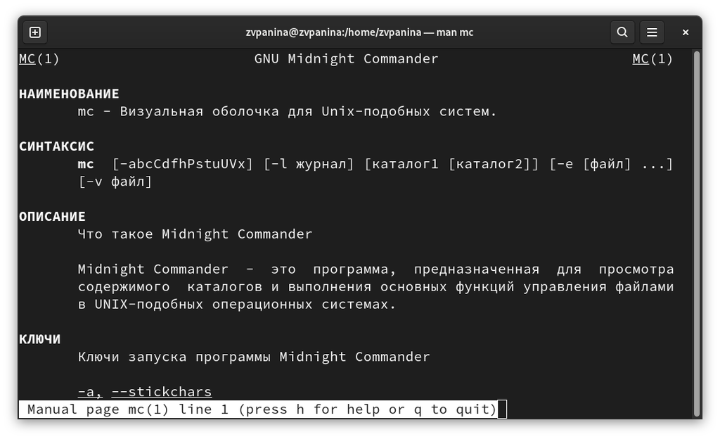

Справка по команде mc

2. Запускаю из командной строки mc, изучаю его структуру и меню.

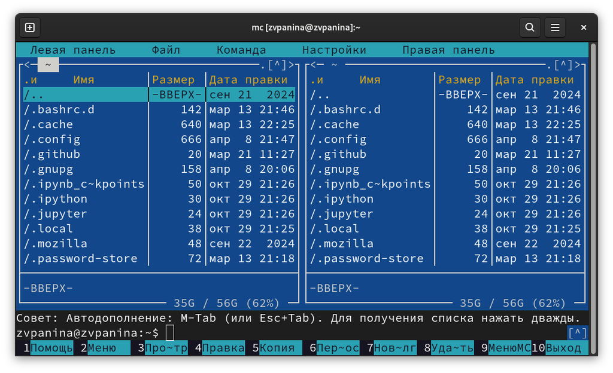

Структура mc

3. Выполняю несколько операций в mc, используя управляющие клавиши. Клавишей Insert выделяю файлы.

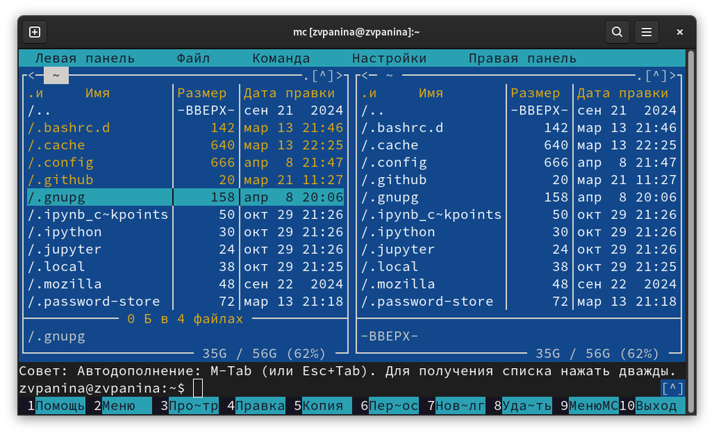

Выделение файлов

Клавишей + выделяю файлы по шаблону.

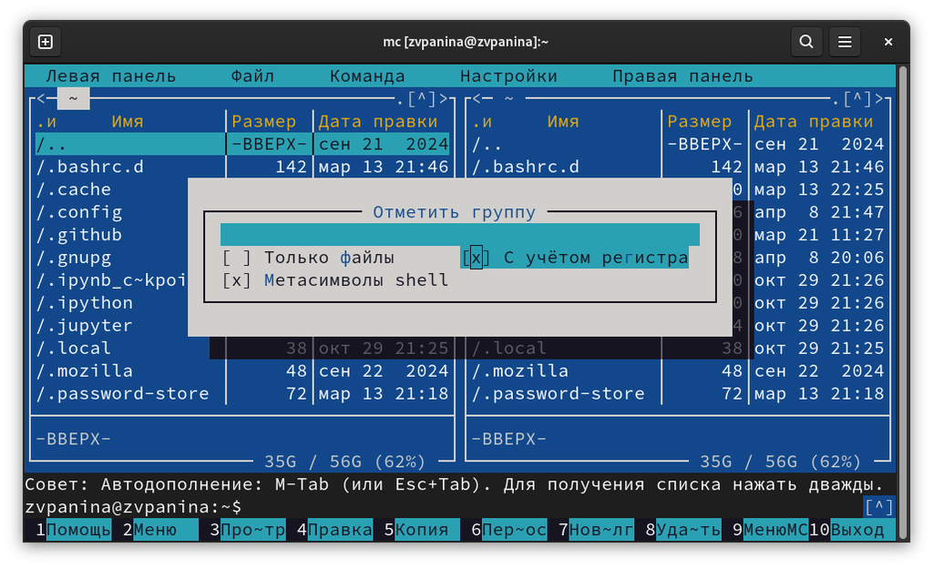

Выделение файлов по шаблону

Клавишей F5 могу скопировать каталог.

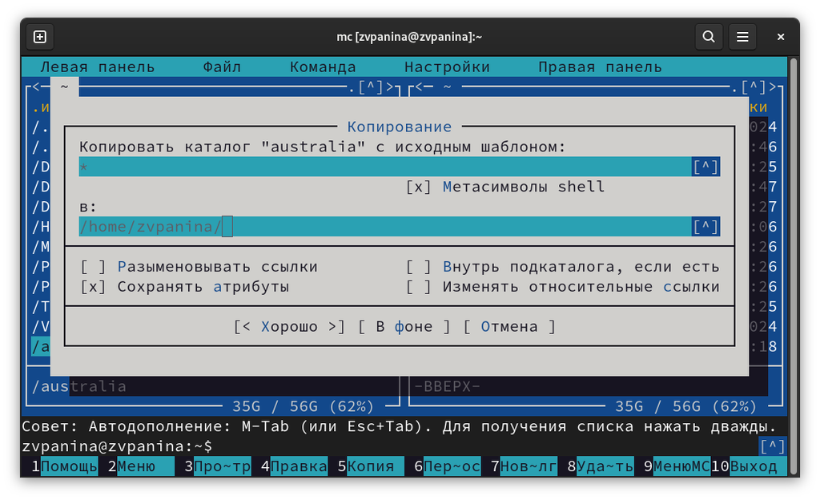

Копирование каталога

Клавишей F6 могу переместить каталог.

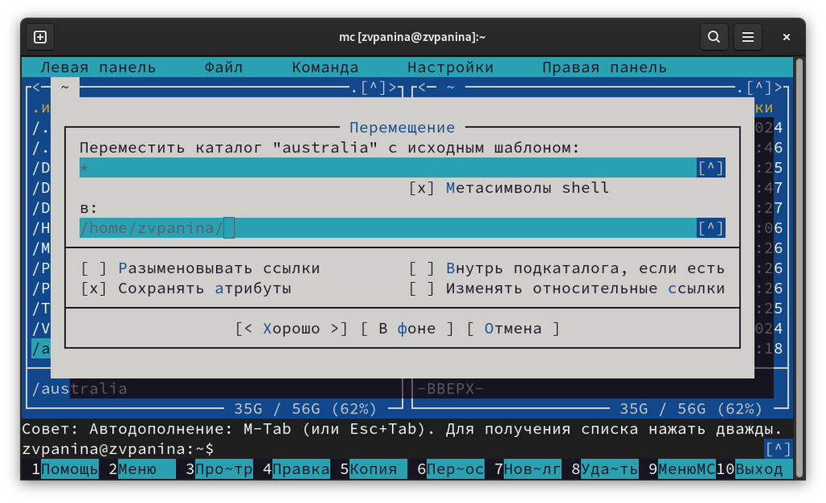

Перемещение каталога

Клавишей F7 могу создать новый каталог.

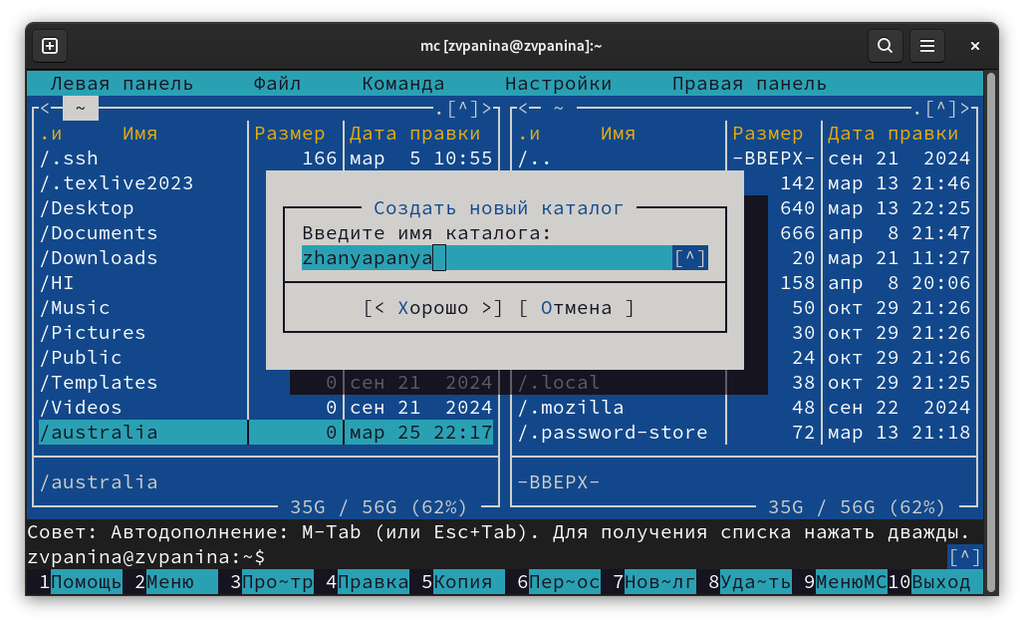

Создание каталога

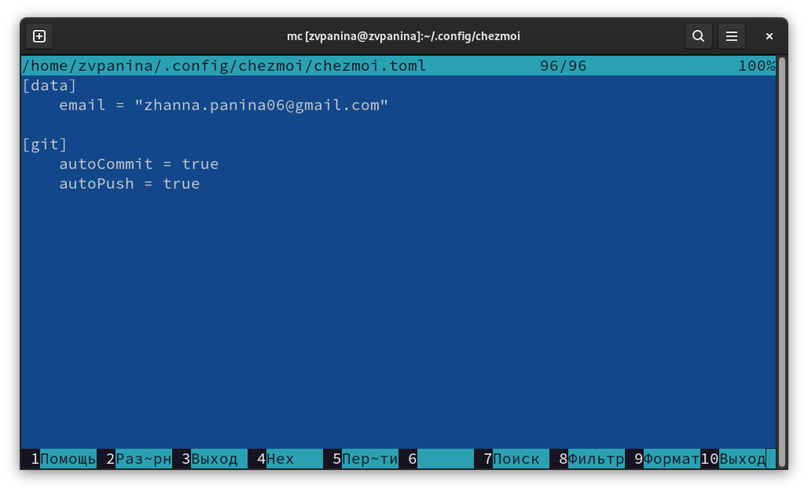

Просмотр содержимого файла

Клавишей F9 и стрелками перемещаюсь в меню файл, где могу просмотреть права доступа

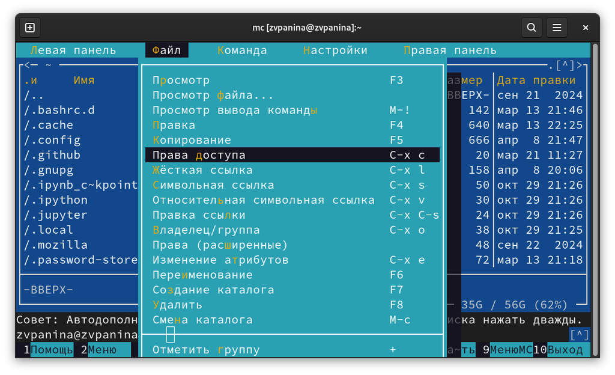

Получение информации о правах доступа

4. Выполняю основные команды меню левой панели. Вывод информации о файлах достаточно подробный: можно увидеть права доступа, атрибуты, владельца, размер файла и т.д.

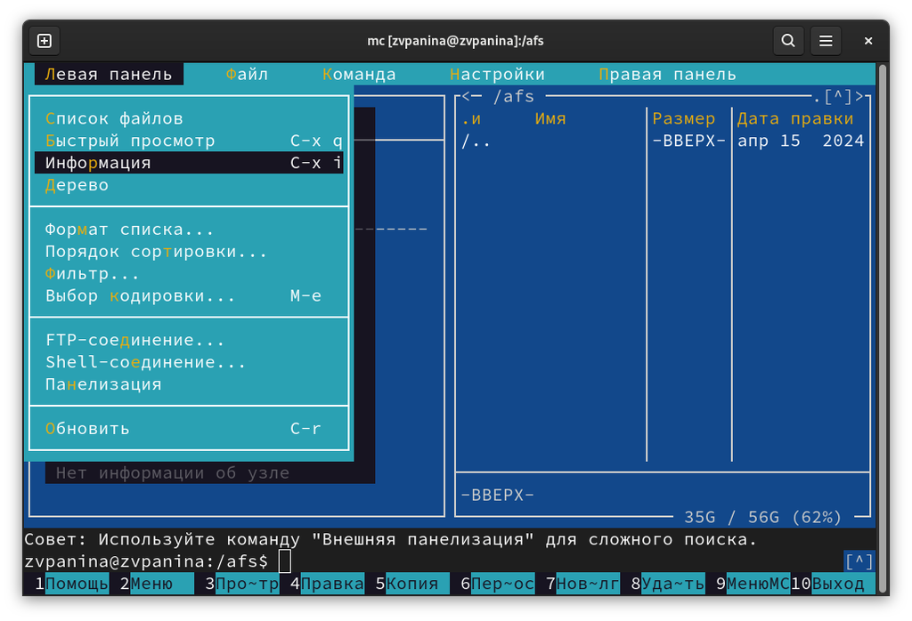

Меню левой панели

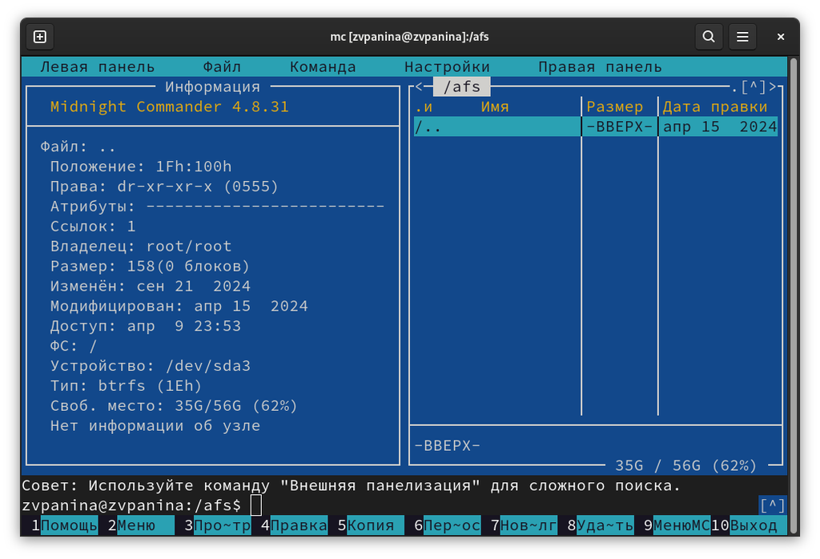

Информация о файле

Просматриваю дерево каталогов.

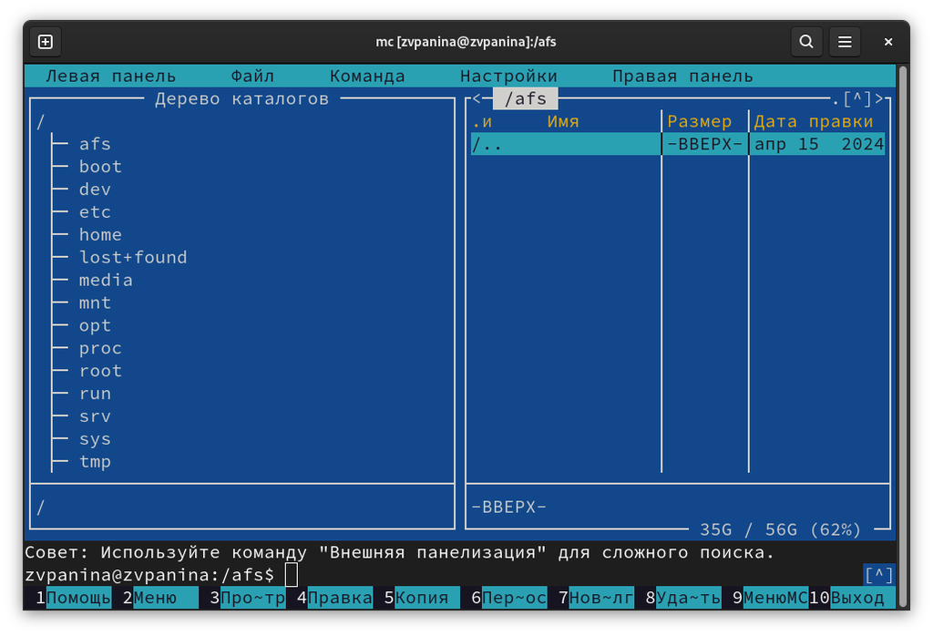

Дерево в меню левой панели

Просматриваю опцию фильтр.

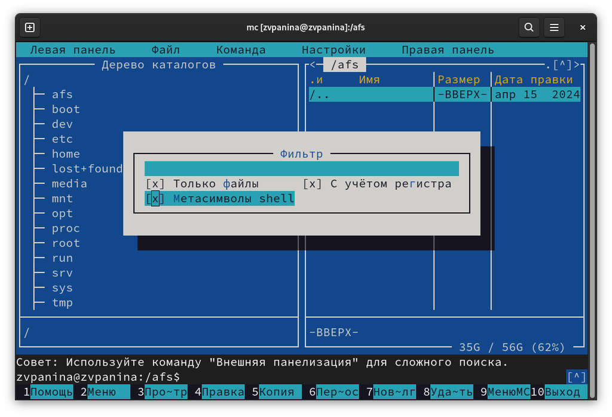

Фильтр в меню левой панели

Просматриваю опцию выбора кодировки в меню.

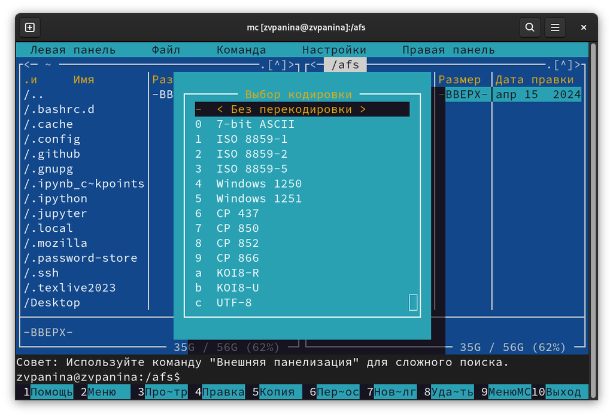

Выбор кодировки

5. С помощью F9 выбираю подменю Файл.

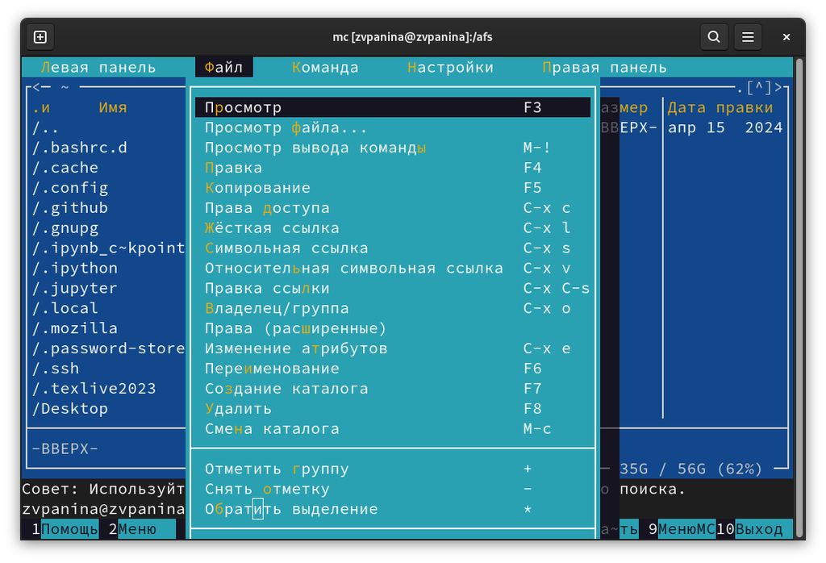

Подменю Файл

Используя возможности подменю Файл, выполняю:

- просмотр содержимого текстового файла с помощью F3

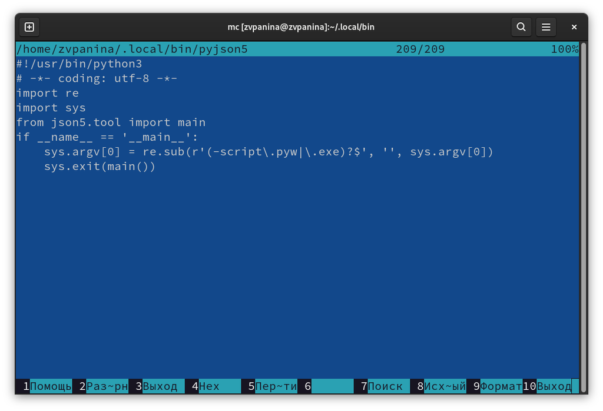

Просмотр содержимого текстового файла

- редактирование содержимого текстового файла с помощью F4 (в каталоге australia создала файл snakes)

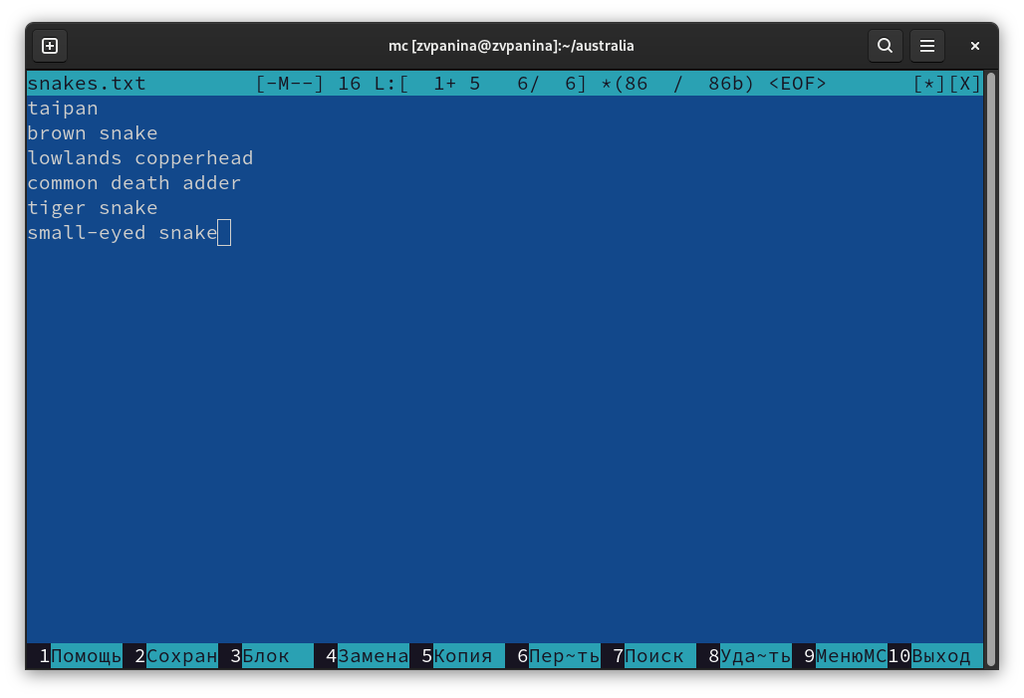

Редактирование текстового файла

- создание каталога с помощью F7.

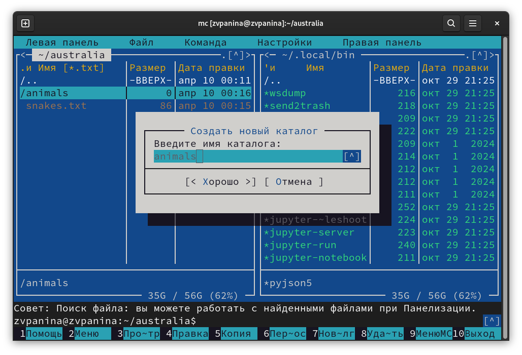

Создание каталога

- копирование файла snakes в созданный каталог animals с помощью F5.

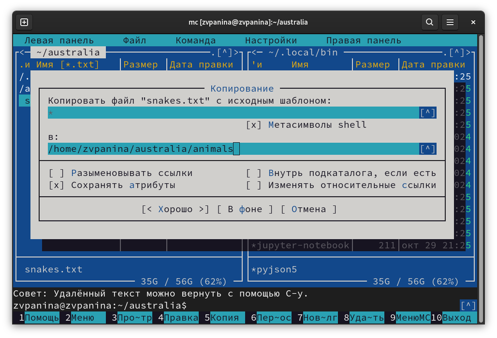

Копирование файла в каталог

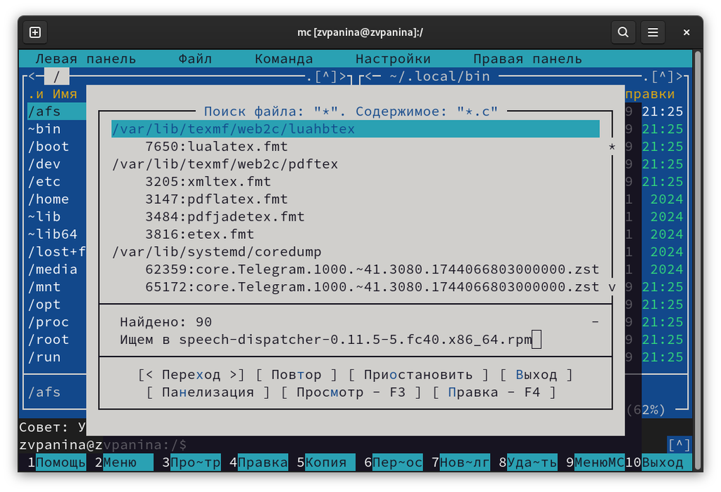

Поиск файла с заданными условиями

- выбор и повторение одной из предыдущих команд (с помощью просмотра истории командной строки).

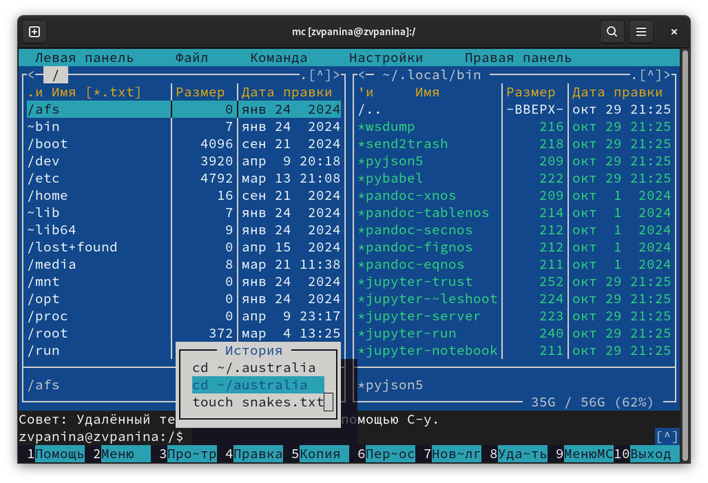

Повторение одной из предыдущих команд

- переход в домашний каталог (с помощью дерева).

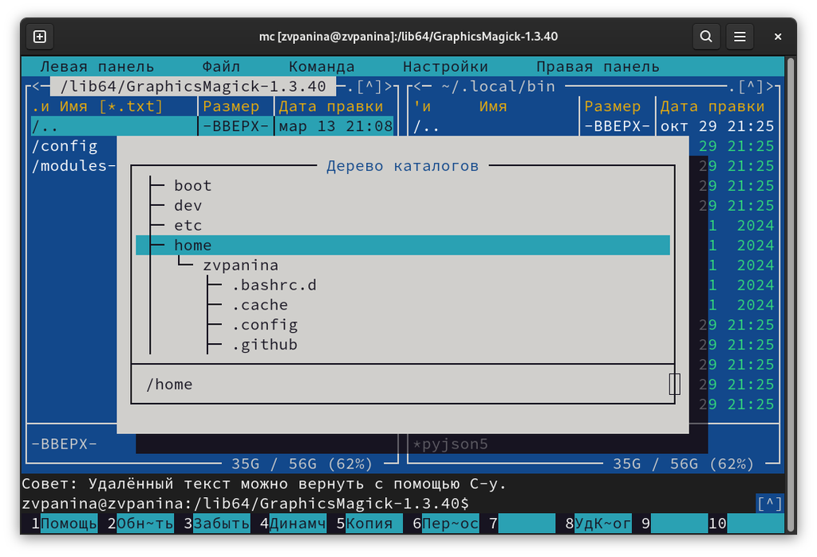

Переход в домашний каталог

- анализ файла меню и файла расширений.

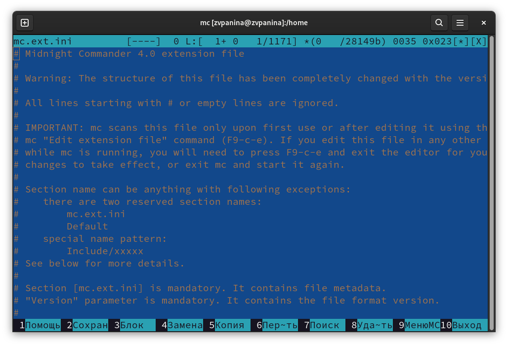

Анализ файла меню и файла расширений

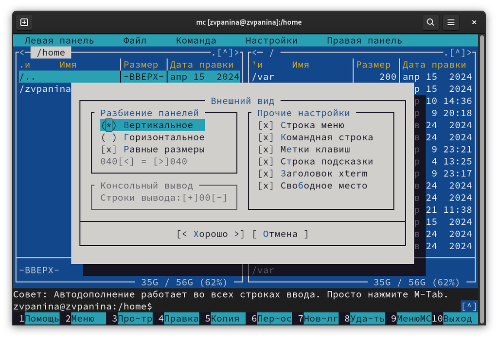

Опция Внешний вид

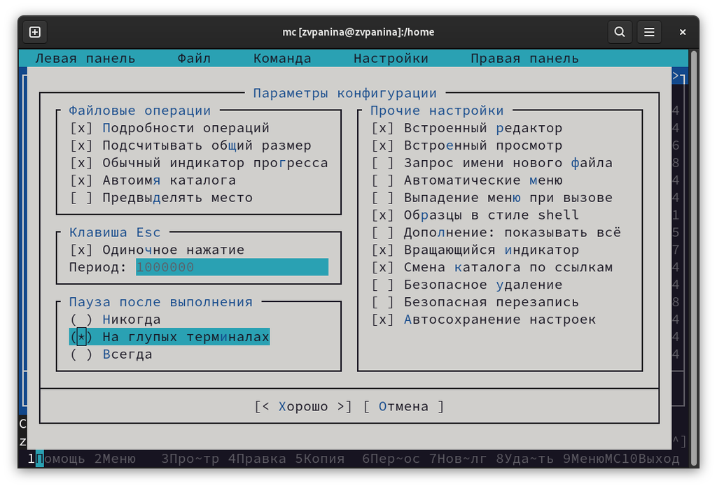

Параметры конфигурации

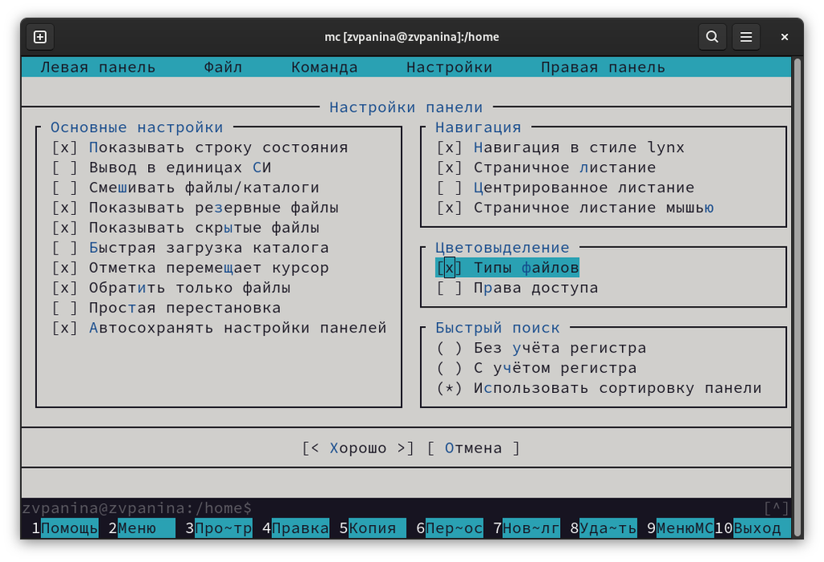

Настройки панели